# case_delays

### Effect of different factors on case processing time

Our data looks like this:

```python
df.iloc[7:12]
```

|  | Case Type | Filing Number | Filing Date | Registration Number | Registration Date | First Hearing Date | Last Hearing Date | Stage of Case | Case Transfered From Establishment | Transfer Date | ... | Under Section(s) | Fir Details | Next Hearing Date | Decision Date | Nature of Disposal | sub_court_DecisionDate | sub_court_CaseNumberAndYear | sub_court_NumberAndName | no_proceedings | decision_days |
| --- | --- | --- | --- | --- | --- | --- | --- | --- | --- | --- | --- | --- | --- | --- | --- | --- | --- | --- | --- | --- | --- |
| MHPU240004042017 | Civil M.A. | 83/2017 | 2017-04-27 | 15/2017 | 2017-04-28 | 2017-04-28 | 2018-10-12 | Notice_Unready | None | NaT | ... | 8 | None | 2018-11-27 | NaT | NaN | NaT | NaN | NaN | 21 | NaN |
| MHPU240004052017 | Civil M.A. | 60/2017 | 2017-04-03 | 13/2017 | 2017-04-28 | 2017-06-05 | 2018-11-12 | Awaiting Summons | None | NaT | ... | 9 | None | 2019-01-04 | NaT | NaN | NaT | NaN | NaN | 13 | NaN |
| MHPU170023772017 | R.C.S. | 446/2017 | 2017-12-27 | 331/2017 | 2017-12-27 | 2017-12-29 | 2018-04-22 | Notice_Unready | None | NaT | ... | NaN | None | 2018-04-22 | 2018-04-22 | LOKADALAT | NaT | NaN | NaN | 4 | 114.0 |
| MHPU170021242017 | R.C.S. | 411/2017 | 2017-12-07 | 321/2017 | 2017-12-07 | 2017-12-08 | 2017-12-09 | Notice_Unready | None | NaT | ... | NaN | None | 2017-12-09 | 2017-12-09 | LOKADALAT | NaT | NaN | NaN | 2 | 1.0 |
| MHPU170021302017 | R.C.S. | 417/2017 | 2017-12-08 | 319/2017 | 2017-12-08 | 2017-12-09 | 2017-12-09 | Notice_Unready | None | NaT | ... | NaN | None | 2017-12-09 | 2017-12-09 | LOKADALAT | NaT | NaN | NaN | 1 | 0.0 |

5 rows × 27 columns

Now we can plot a corelation between no_proceedings and decision_days.

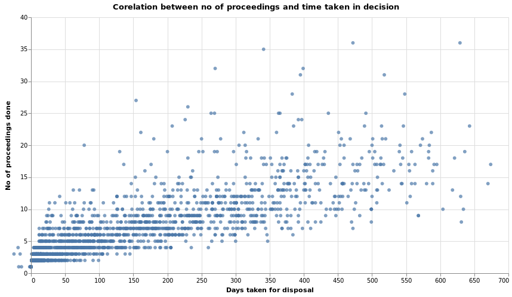

The general pattern is that as the number of proceedings increase, the time taken in disposal also increase.

But we also see that there are many cases where proceedings were more but disposal was fast.  
This hints us to look for other factors that are responsible for delay in disposals.

Let's look at how type of a case affects the disposal time.

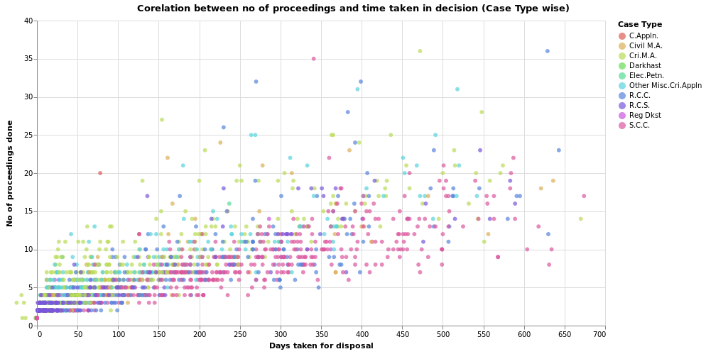

So we see, that when the number of proceedings are similar the case types differ, that means some case types are processed faster than others.  
But again, we have same case types with similar proceeding count but different disposal times.

Let us see how the case handling Judge affects the time.

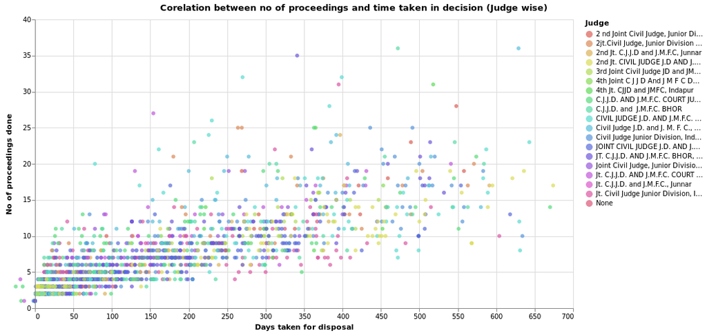

So we see, the cases that have same hearings and disposed at different times have different judges most of the time.  
Let's look deeper into it.

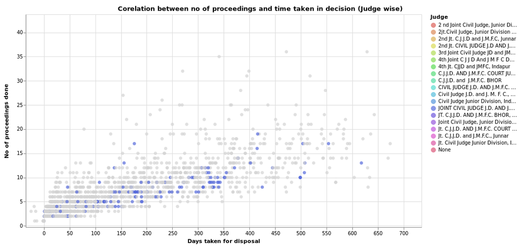

So it doesn't make much difference, we see the same judge processing the case in different times given same no of proceedings.

Though we also have examples of when a judge does breaks this pattern (at least to some extent).

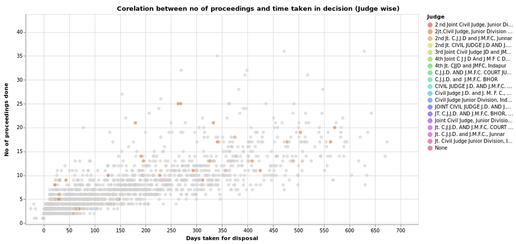

So we need to look more into the data to find out what affects the disposal time most.